# OncoSimulR: forward genetic simulation in asexual populations with arbitrary epistatic interactions and a focus on modeling tumor progression.

## 10.6 Frequency-dependent fitness: can I use genes with mutator effects?

Yes. The following examples show it:

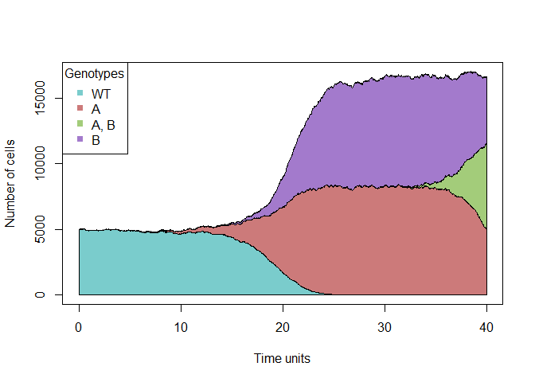

```r
## Relative
r1fd <- data.frame(Genotype = c("WT", "A", "B", "A, B"),
                 Fitness = c("1",
                             "1.4 + 1*(f_2)",
                             "1.4 + 1*(f_1)",
                             "1.6 + f_1 + f_2"))
afe4 <- allFitnessEffects(genotFitness = r1fd,
                         frequencyDependentFitness = TRUE,
                         frequencyType = "rel")


set.seed(1)
s1fd <- oncoSimulIndiv(afe4,
                     model = "McFL",
                     onlyCancer = FALSE,
                     finalTime = 40,
                     mu = 1e-4,
                     initSize = 5000,
                     keepPhylog = TRUE,
                     seed = NULL,
                     errorHitMaxTries = FALSE,
                     errorHitWallTime = FALSE)
plot(s1fd, show = "genotypes")
```

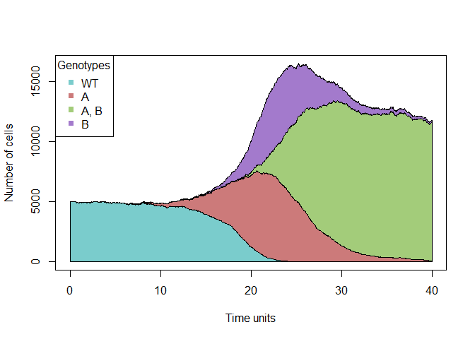

```r
mtfd <- allMutatorEffects(epistasis = c("A" = 0.1,
                                      "B" = 10))
set.seed(1)
s2fd <- oncoSimulIndiv(afe4,
                     muEF = mtfd,
                     model = "McFL",
                     onlyCancer = FALSE,
                     finalTime = 40,
                     mu = 1e-4,
                     initSize = 5000,
                     keepPhylog = TRUE,
                     seed = NULL,
                     errorHitMaxTries = FALSE,
                     errorHitWallTime = FALSE)
plot(s2fd, show = "genotypes")
```

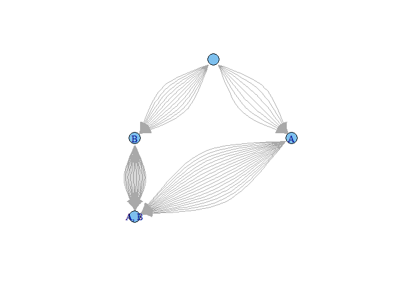

```r
plotClonePhylog(s1fd, keepEvents = TRUE)
```

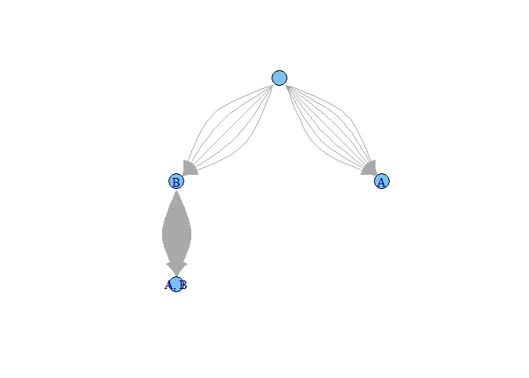

```r
plotClonePhylog(s2fd, keepEvents = TRUE)
```

Of course, it also works with absolute frequencies (code not executed for the sake of speed):

```r
## Absolute
r5 <- data.frame(Genotype = c("WT", "A", "B", "A, B"),
                 Fitness = c("1",
                             "1.25 - .0025*(n_2)",
                             "1.25 - .0025*(n_1)",
                             "1.4"),
                 stringsAsFactors = FALSE)

afe5 <- allFitnessEffects(genotFitness = r5,
                         frequencyDependentFitness = TRUE,
                         frequencyType = "abs")
set.seed(8)
s5 <- oncoSimulIndiv(afe5,
                     model = "McFL",
                     onlyCancer = FALSE,
                     finalTime = 100,
                     mu = 1e-4,
                     initSize = 5000,
                     keepPhylog = TRUE,
                     seed = NULL,
                     errorHitMaxTries = FALSE,
                     errorHitWallTime = FALSE)
plot(s5, show = "genotypes")
plot(s5, show = "genotypes", log = "y", type = "line")

mt <- allMutatorEffects(epistasis = c("A" = 0.1,
                                      "B" = 10))
set.seed(8)
s6 <- oncoSimulIndiv(afe5,
                     muEF = mt,
                     model = "McFL",
                     onlyCancer = FALSE,
                     finalTime = 100,
                     mu = 1e-4,
                     initSize = 5000,
                     keepPhylog = TRUE,
                     seed = NULL,
                     errorHitMaxTries = FALSE,
                     errorHitWallTime = FALSE)
plot(s6, show = "genotypes")
plot(s6, show = "genotypes", log = "y", type = "line")

plotClonePhylog(s5, keepEvents = TRUE)
plotClonePhylog(s6, keepEvents = TRUE)
```

Note that **evalAllGenotypesFitAndMut** currently works with frequency-dependent fitness:

```r
evalAllGenotypes(allFitnessEffects(genotFitness = r1fd,
                                   frequencyDependentFitness = TRUE,
                                   frequencyType = "rel"),
                 spPopSizes = c(10, 20, 30, 40))
## Warning in match_spPopSizes(spPopSizes, fmEffects): spPopSizes
## unnamed: cannot check genotype names.
##   Genotype Fitness
## 1       WT     1.0
## 2        A     1.7
## 3        B     1.6
## 4     A, B     2.1


evalAllGenotypesFitAndMut(allFitnessEffects(genotFitness = r1fd,
                                   frequencyDependentFitness = TRUE,
                                            frequencyType = "rel"),
                          mtfd,
                          spPopSizes = c(10, 20, 30, 40))
## Warning in match_spPopSizes(spPopSizes, fitnessEffects): spPopSizes
## unnamed: cannot check genotype names.
##   Genotype Fitness MutatorFactor
## 1       WT     1.0           1.0
## 2        A     1.7           0.1
## 3        B     1.6          10.0
## 4     A, B     2.1           1.0
```

## 10.7 Can we use the BNB algorithm to model frequency-dependent fitness?

This question is similar to the one we address in 15.6. Briefly, the answer is yes. You can think of this as an approximation to an exact simulation of a stochastic system. You can also think of a delay in the system in the sense that the changes in rates due to changes in the frequencies of the different genotypes are updated at periodic intervals, not immediately.

# 11 Additional examples of frequency-dependent fitness

Note also that in most of these examples we make rather arbitrary and simple assumptions about the genetic basis of the different phenotypes or strategies (most are one-mutation-away from WT); see 10.4 and 10.2 (where we change the ancestor-dependent relationships). In some examples mutation rates are also very high, to speed up processes and because a high mutation rate is used as a procedure (a hack?) to quickly obtain descendants from WT (i.e., to get the game started with some representatives of the non-WT types).

Examples 11.1, 11.2, 11.3, 11.4, 11.5 were originally prepared by Sara Dorado Alfaro, Miguel Hernández del Valle, Álvaro Huertas García, Diego Mañanes Cayero, Alejandro Martín Muñoz; example 11.6 was originally prepared by Marta Couce Iglesias, Silvia García Cobos, Carlos Madariaga Aramendi, Ana Rodríguez Ronchel, and Lucía Sánchez García; examples 11.7, 11.8, 11.9 were prepared by Yolanda Benítez Quesada, Asier Fernández Pato, Esperanza López López, Alberto Manuel Parra Pérez. All of these as an exercisse for the course Programming and Statistics with R (Master’s Degree in Bioinformatics and Computational Biology, Universidad Autónoma de Madrid), course 2019-20.

## 11.1 Rock-paper-scissors model in bacterial community

### 11.1.1 Introduction

This example is inspired by Kerr et al. (2002). It describes the relationship between three populations of *Escherichia coli*, that turns out to be very similar to a rock-paper-scissors game.

An E. coli community can have a specific strain of colicinogenic bacteria, that are capable of creating colicin, a toxin to which this special strain is resistant. The wild-type bacteria is killed by this toxin, but can mutate into a resistant strain.

So, there are three kinds of bacteria: wild-type (WT), colicinogenic (C) and resistant (R). The presence of C reduces the population of WT, but increases the population of R because R has an advantage over C, since R doesn’t have the cost of creating the toxin. At the same time, WT has an advantage over R, because by losing the toxin receptors, R loses also some important functions. Therefore, every strain “wins” against one strain and “loses” against the other, creating a rock-paper-scissors game.

```r
crs <- function (a, b, c){
  data.frame(Genotype = c("WT", "C", "R"),
             Fitness = c(paste0("1 + ", a, " * f_R - ", b, " * f_C"),
                         paste0("1 + ", b, " * f_ - ", c, " * f_R"),
                         paste0("1 + ", c, " * f_C - ", a, " * f_")
             ))
}
```

The equations are:

$$\begin{align}
W\left(WT\right) = 1 + af_R - bf_C\\
W\left(C\right) = 1 + bf_{WT} - cf_R\\
W\left(R\right) = 1 + cf_C - af_{WT}\\
\end{align}$$

where $f_{WT}$, $f_C$ and $f_R$ are the frequencies of WT, C and R, respectively.

```r
crs("a", "b", "c")
##   Genotype               Fitness
## 1       WT 1 + a * f_R - b * f_C
## 2        C  1 + b * f_ - c * f_R
## 3        R  1 + c * f_C - a * f_
```

#### 11.1.1.1 Case 1

We are going to study the scenario in which all the relationships have the same relative weight.

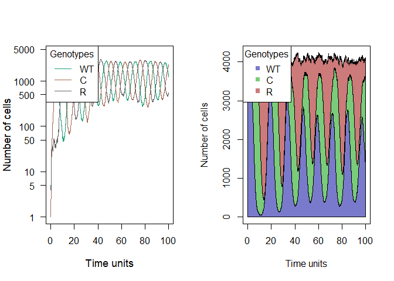

```r
afcrs1 <- allFitnessEffects(genotFitness = crs(1, 1, 1),
                           frequencyDependentFitness = TRUE,
                           frequencyType = "rel")

resultscrs1 <- oncoSimulIndiv(afcrs1,
                             model = "McFL",
                             onlyCancer = FALSE,
                             finalTime = 100,
                             mu = 1e-2,
                             initSize = 4000,
                             keepPhylog = TRUE,
                             seed = NULL,
                             errorHitMaxTries = FALSE,
                             errorHitWallTime = FALSE)
op <- par(mfrow = c(1, 2))
plot(resultscrs1, show = "genotypes", type = "line", cex.lab=1.1,
     las = 1)
plot(resultscrs1, show = "genotypes", type = "stacked")
```

```r
par(op)
```

An oscillatory equilibrium is reached, in which the same populations have a similar number of individuals but oscillates. This makes sense, because the rise on a particular strand will lead to a rise in the one that “wins” against it, and then to a rise in the one that “wins” against the second one, creating this cyclical behaviour. In the stacked plot we can see that the total population remains almost constant.

Note, though, that altering mutation rate (which is huge here) can change the results of the model.

#### 11.1.1.2 Case 2

We are going to put a bigger weight in one of the coefficients, so a=10, b=1, c=1.

```r
afcrs2 <- allFitnessEffects(genotFitness = crs(10, 1, 1),
                           frequencyDependentFitness = TRUE,
                           frequencyType = "rel")
```

If we run multiple simulations, for example by doing

```r
resultscrs2 <- oncoSimulPop(10,
                           afcrs2,
                             model = "McFL",
                             onlyCancer = FALSE,
                             finalTime = 100,
                             mu = 1e-2,
                             initSize = 4000,
                             keepPhylog = TRUE,
                             seed = NULL,
                             errorHitMaxTries = FALSE,
                             errorHitWallTime = FALSE)
```

we can verify there are two different scenarios.

The first one is the one in which all the strains coexist, with the colicinogenic bacteria having a much bigger population.

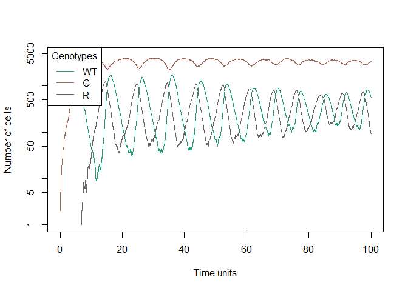

```r
set.seed(1)

resultscrs2a <- oncoSimulIndiv(afcrs2,
                             model = "McFL",
                             onlyCancer = FALSE,
                             finalTime = 100,
                             mu = 1e-2,
                             initSize = 4000,
                             keepPhylog = TRUE,
                             seed = NULL,
                             errorHitMaxTries = FALSE,
                             errorHitWallTime = FALSE)

plot(resultscrs2a, show = "genotypes", type = "line")
```

In the second one, the wild type and the colicinogenic bacteria dissapear, so the resistant strain is the only one that survives.

As above, though, decreasing the mutation rate can lead to a different solution and you will want to run the model for much longer to see the resistant strain appear and outcompete the others.

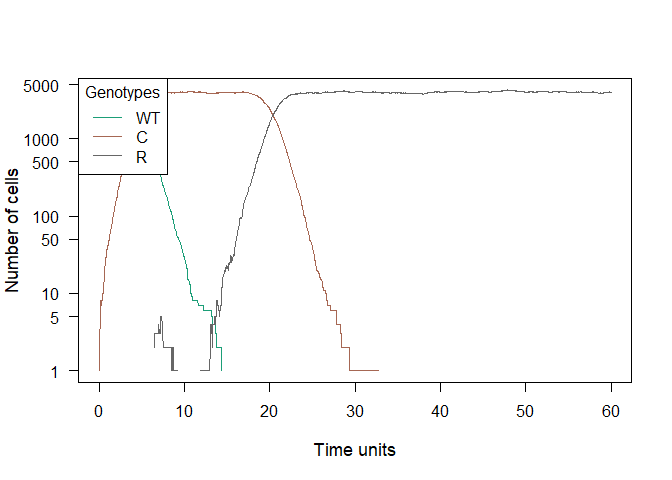

```r
set.seed(3)

resultscrs2b <- oncoSimulIndiv(afcrs2,
                             model = "McFL",
                             onlyCancer = FALSE,
                             finalTime = 60,
                             mu = 1e-2,
                             initSize = 4000,
                             keepPhylog = TRUE,
                             seed = NULL,
                             errorHitMaxTries = FALSE,
                             errorHitWallTime = FALSE)

plot(resultscrs2b, show = "genotypes", type = "line", cex.lab=1.1,
     las = 1)
```

#### 11.1.1.3 Case 3

Finally, we are going to put more weight in two coefficients, so a=1, b=5, c=5.

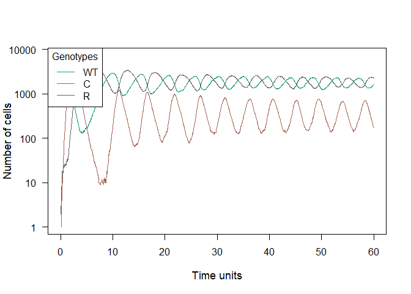

```r
afcrs3 <- allFitnessEffects(genotFitness = crs(1, 5, 5),
                           frequencyDependentFitness = TRUE,
                           frequencyType = "rel")

resultscrs3 <- oncoSimulIndiv(afcrs3,
                             model = "McFL",
                             onlyCancer = FALSE,
                             finalTime = 60,
                             mu = 1e-2,
                             initSize = 4000,
                             keepPhylog = TRUE,
                             seed = NULL,
                             errorHitMaxTries = FALSE,
                             errorHitWallTime = FALSE)

plot(resultscrs3, show = "genotypes", type = "line", cex.lab=1.1,
     las = 1)
```

## 11.2 Hawk and Dove example

The example we are going to show is one of the first games that Maynard Smith analyzed, for example in his classic Maynard Smith (1982) (see also, e.g., https://en.wikipedia.org/wiki/Chicken_%28game%29 ).

In this game, the two competitors are subtypes of the same species but with different strategies. The Hawk first displays aggression, then escalates into a fight until it either wins or is injured (loses). The Dove first displays aggression, but if faced with major escalation runs for safety. If not faced with such escalation, the Dove attempts to share the resource (see the payoff matrix, for instance in https://en.wikipedia.org/wiki/Chicken_%28game%29#Hawk%E2%80%93dove ).

Given that the resource is given the value V, the damage from losing a fight is given cost C:

- If a Hawk meets a Dove he gets the full resource V to himself
- If a Hawk meets a Hawk – half the time he wins, half the time he loses… so his average outcome is then V/2 minus C/2
- If a Dove meets a Hawk he will back off and get nothing – 0
- If a Dove meets a Dove both share the resource and get V/2

The actual payoff however depends on the probability of meeting a Hawk or Dove, which in turn is a representation of the percentage of Hawks and Doves in the population when a particular contest takes place. That in turn is determined by the results of all of the previous contests. If the cost of losing C is greater than the value of winning V (the normal situation in the natural world) the mathematics ends in an stationary point (ESS), a mix of the two strategies where the population of Hawks is V/C.

In this case we assume a stable equilibrium in the population dynamics, that is, although there are external variations in the model, it recovers and returns to equilibrium.

We are going to simulate with OncoSimulR the situation in which the cost of losing C is greater than the value of gaining V (C = 10, V = 2). We assume that both Hawk and Dove are derived from WT by one mutation (see also 10.4) and we will use very high mutation rates to get some hawks and doves from WT quickly (see above).

Before performing the simulation, let’s look at the fitness of each competitor.

```r
## Stablish Genotype-Fitnees mapping. D = Dove, H = Hawk

## With newer OncoSimulR functionality, using WT to start the simulation
## would no longer be needed.
H_D_fitness <- function(c, v,
                    gt = c("WT", "H", "D")) {
  data.frame(Genotype = gt,
             Fitness = c(
               paste0("1"),
               paste0("1 + f_H *", (v-c)/2, "+ f_D *", v),
               paste0("1 + f_D *", v/2)))
}

## Fitness Effects specification
HD_competition <-allFitnessEffects(
  genotFitness = H_D_fitness(10, 2,
                         gt = c("WT", "H", "D")),
  frequencyDependentFitness = TRUE,
  frequencyType = "rel")

## Plot fitness landscape of genotype "H, D" evaluation
data.frame("Doves_fitness" = evalGenotype(genotype = "D",
                                          fitnessEffects = HD_competition,
                                          spPopSizes = c(5000, 5000, 5000)),
           "Hawks_fitness" = evalGenotype(genotype = "H",
                                          fitnessEffects = HD_competition,
                                          spPopSizes = c(5000, 5000, 5000))
           )
## Warning in match_spPopSizes(spPopSizes, fmEffects): spPopSizes
## unnamed: cannot check genotype names.

## Warning in match_spPopSizes(spPopSizes, fmEffects): spPopSizes
## unnamed: cannot check genotype names.
##   Doves_fitness Hawks_fitness
## 1      1.333333     0.3333333
```

We observe that the penalty of fighting (C > V) benefits the dove in terms of fitness respect to the hawk.

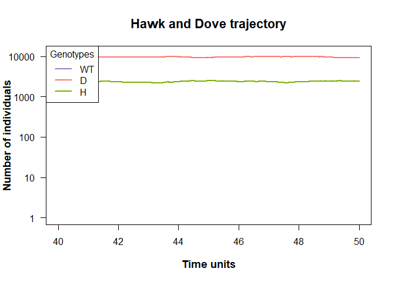

```r
## Simulated trajectories
## run only a few for the sake of speed
simulation <- oncoSimulPop(2,
                           mc.cores = 2,
                           HD_competition,
                           model = "McFL", # There is no collapse
                           onlyCancer = FALSE,
                           finalTime = 50,
                           mu = 1e-2, # Quick emergence of D and H
                           initSize = 4000,
                           keepPhylog = TRUE,
                           seed = NULL,
                           errorHitMaxTries = FALSE,
                           errorHitWallTime = FALSE)



## Plot first trajectory as an example
plot(simulation[[1]], show = "genotypes", type = "line",
    xlim = c(40, 50),
     lwdClone = 2, ylab = "Number of individuals",
     main = "Hawk and Dove trajectory",
     col = c("#a37acc", "#f8776d", "#7daf00"),
     font.main=2, font.lab=2,
     cex.main=1.4, cex.lab=1.1,
     las = 1)
```

As mentioned above, mathematically when a stationary point (ESS) is reached the relative frequency of hawks is V/C and doves 1-(V/C). Considering f_H as relative frecuency of hawks and f_D = 1-f_H as frequency of doves:

Hawk:
$$1 + f_H*(v-c)/2 + (1-f_H)*v$$

Dove:
$$1 + (1-f_H)*v/2$$

Hawk = Dove:
$$1 + f_H*(v-c)/2 + (1-f_H)*v = 1 + (1-f_H)*v/2$$

Resolving for f_H:
$$f_H = v/c$$

Therefore, the relative frequency of hawks in equilibrium is equal to V/C. In our case it would be 20% (C = 10, V = 2). Let’s check it:

```r
## Recover the final result from first simulation
result <- tail(simulation[[1]][[1]], 1)

## Get the number of organisms from each species
n_WT <- result[2]
n_D <- result[3]
n_H <- result[4]
total <- n_WT + n_D + n_H

## Dove percentage
data.frame("Doves" = round(n_D/total, 2)*100,
           "Hawks" = round(n_H/total, 2)*100  )
##   Doves Hawks
## 1    79    21
```

To sum up, this example shows that when the risks of contest injury or death (the Cost C) is significantly greater than the potential reward (the benefit value V), the stable population will be mixed between aggressors and doves, and the proportion of doves will exceed that of the aggressors. This explains behaviours observed in nature.

## 11.3 Game Theory with social dilemmas of tumour acidity and vasculature

This example is based on Kaznatcheev et al. (2017). In this work, it is explained that the progression of cancer is marked by the acquisition of a number of hallmarks, including self-sufficiency of growth factor production for angiogenesis and reprogramming energy metabolism for aerobic glycolysis. Moreover, there is evidence of intra-tumour heterogeneity. Given that some cancer cells can not invest in something that benefits the whole tumor while others can free-ride on the benefits created by them (evolutionary social dilemmas), how do these population level traits evolve, and how are they maintained? The authors answer this question with a mathematical model that treats acid production through glycolysis as a tumour-wide public good that is coupled to the club good of oxygen from better vascularisation.

The cell types of the model are:

- VOP: VEGF (over)-producers.
- GLY: glycolytic cells.
- DEF: aerobic cells that do not call for more vasculature.

On the other hand, the micro-environmental parameters of the model are:

- a: the benefit per unit of acidification.
- v: the benefit from oxygen per unit of vascularisation.
- c: the cost of (over)-producing VEGF.

The fitness equations derived from those populations and parameters are:

$$\begin{equation}
W\left(GLY\right) = 1 + a * \left(f_1 + 1\right)
\end{equation}$$
$$\begin{equation}
W\left(VOP\right) = 1 + a * f_1 + v * \left(f_2 + 1\right) - c
\end{equation}$$
$$\begin{equation}
W\left(DEF\right) = 1 + a * f_1 + v * f_2
\end{equation}$$

Where $f_1$ is the GLY cells’ frequency and $f_2$ is the VOF cells’ frequency at a given time. All fitness equations start from balance by the sum of 1.

Finally, depending of the parameter’s values, the model can lead to three different situations (as in other examples, the different types are one mutation away from WT):

### 11.3.1 Fully glycolytic tumours:

If the fitness benefit of a single unit of acidification is higher than the maximum benefit from the club good for aerobic cells, then GLY cells will always have a strictly higher fitness than aerobic cells, and be selected for. In this scenario, the population will converge towards all GLY, regardless of the initial proportions (as long as there is at least some GLY in the population).

```r
# Definition of the function for creating the corresponding dataframe.
avc <- function (a, v, c) {
  data.frame(Genotype = c("WT", "GLY", "VOP", "DEF"),
             Fitness = c("1",
                         paste0("1 + ",a," * (f_GLY + 1)"),
                         paste0("1 + ",a," * f_GLY + ",v," * (f_VOP + 1) - ",c),
                         paste0("1 + ",a," * f_GLY + ",v," * f_VOP")
                         ))
                          }

# Specification of the different effects on fitness.
afavc <- allFitnessEffects(genotFitness = avc(2.5, 2, 1),
                           frequencyDependentFitness = TRUE,
                           frequencyType = "rel")

## For real, you would probably want to run
## this multiple times with oncoSimulPop
simulation <- oncoSimulIndiv(afavc,
                           model = "McFL",
                           onlyCancer = FALSE,
                           finalTime = 15,
                           mu = 1e-3,
                           initSize = 4000,
                           keepPhylog = TRUE,
                           seed = NULL,
                           errorHitMaxTries = FALSE,
                           errorHitWallTime = FALSE)
```

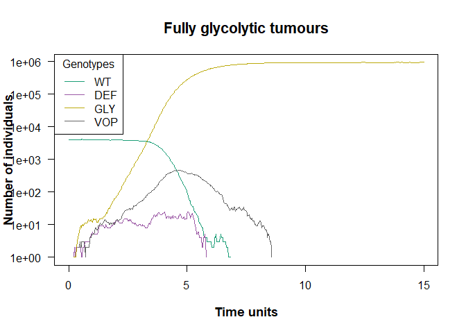

```r
# Representation of the plot of one simulation as an example (the others are
# highly similar).
plot(simulation, show = "genotypes", type = "line",
     ylab = "Number of individuals", main = "Fully glycolytic tumours",
     font.main=2, font.lab=2, cex.main=1.4, cex.lab=1.1, las = 1)
```

### 11.3.2 Fully angiogenic tumours:

If the benefit to VOP from their extra unit of vascularisation is higher than the cost c to produce that unit, then VOP will always have a strictly higher fitness than DEF, selecting the proportion of VOP cells towards 1. In addition, if the maximum possible benefit of the club good to aerobic cells is higher than the benefit of an extra unit of acidification, then for sufficiently high number of VOP, GLY will have lower fitness than aerobic cells. When both conditions are satisfied, the population will converge towards all VOP.

```r
# Definition of the function for creating the corresponding dataframe.
avc <- function (a, v, c) {
  data.frame(Genotype = c("WT", "GLY", "VOP", "DEF"),
             Fitness = c("1",
                         paste0("1 + ",a," * (f_GLY + 1)"),
                         paste0("1 + ",a," * f_GLY + ",v, " * (f_VOP + 1) - ",c),
                         paste0("1 + ",a," * f_GLY + ",v, " * f_VOP")
                         ))
                          }

# Specification of the different effects on fitness.
afavc <- allFitnessEffects(genotFitness = avc(2.5, 7, 1),
                           frequencyDependentFitness = TRUE,
                           frequencyType = "rel")

simulation <- oncoSimulIndiv(afavc,
                           model = "McFL",
                           onlyCancer = FALSE,
                           finalTime = 15,
                           mu = 1e-4,
                           initSize = 4000,
                           keepPhylog = TRUE,
                           seed = NULL,
                           errorHitMaxTries = FALSE,
                           errorHitWallTime = FALSE)
```

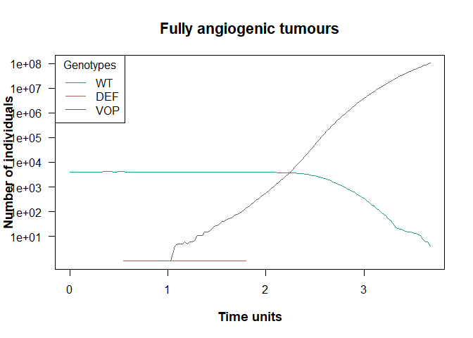

```r
## We get a huge number of VOP very quickly
## (too quickly?)
plot(simulation, show = "genotypes", type = "line",
     ylab = "Number of individuals", main = "Fully angiogenic tumours",
     font.main=2, font.lab=2, cex.main=1.4, cex.lab=1.1, las = 1)
```

### 11.3.3 Heterogeneous tumours:

If the benefit from an extra unit of vascularisation in a fully aerobic group is lower than the cost c to produce that unit, then for a sufficiently low proportion of GLY and thus sufficiently large number of aerobic cells sharing the club good, DEF will have higher fitness than VOP. This will lead to a decrease in the proportion of VOP among aerobic cells and thus a decrease in the average fitness of aerobic cells. A lower fitness in aerobic cells will lead to an increase in the proportion of GLY until the aerobic groups (among which the club good is split) get sufficiently small and fitness starts to favour VOP over DEF, swinging the dynamics back.

```r
# Definition of the function for creating the corresponding dataframe.
avc <- function (a, v, c) {
  data.frame(Genotype = c("WT", "GLY", "VOP", "DEF"),
             Fitness = c("1",
                         paste0("1 + ",a," * (f_GLY + 1)"),
                         paste0("1 + ",a," * f_GLY + ",v," * (f_VOP + 1) - ",c),
                         paste0("1 + ",a," * f_GLY + ",v," * f_VOP")
                         ))
                          }

# Specification of the different effects on fitness.
afavc <- allFitnessEffects(genotFitness = avc(7.5, 2, 1),
                           frequencyDependentFitness = TRUE,
                           frequencyType = "rel")

# Launching of the simulation (20 times).
simulation <- oncoSimulIndiv(afavc,
                           model = "McFL",
                           onlyCancer = FALSE,
                           finalTime = 25,
                           mu = 1e-4,
                           initSize = 4000,
                           keepPhylog = TRUE,
                           seed = NULL,
                           errorHitMaxTries = FALSE,
                           errorHitWallTime = FALSE)
```

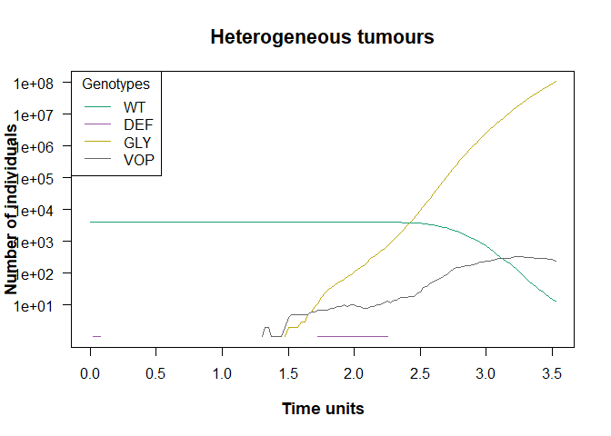

```r
# Representation of the plot of one simulation as an example (the others are
# highly similar).
plot(simulation, show = "genotypes", type = "line",
     ylab = "Number of individuals", main = "Heterogeneous tumours",
     font.main=2, font.lab=2, cex.main=1.4, cex.lab=1.1, las = 1)
```

## 11.4 Prostate cancer tumour–stroma interactions

This example is based on Basanta et al. (2012). The authors apply evolutionary game theory to model the behavior and progression of a prostate tumour formed by three different cell populations: stromal cells, a dependant tumour phenotype capable of co-opting stromal cells to support its growth and an independent tumour phenotype that does not require microenvironmental support, be it stromal associated or not. To enable this, the model has four variables, which is the minimun necessary to describe the relationships in terms of costs and benefits between the different types of cells and, of course, to describe the progression of the cancer.

The different cell types, hence, are as follows:

1. S: stromal cells.
2. D: microenvironmental-dependent tumour cells.
3. I: microenvironmental-independent tumour cells.

And the parameters that describe the relationships are as follows:

- $\alpha$: benefit derived from the cooperation between a S cell and a D cell.
- $\beta$: cost of extracting resources from the microenvironment.
- $\gamma$: cost of being microenvironmentally independent.
- $\rho$: benefit derived by D from paracrine growth factors produced by I cells.

Table 11.1 shows the payoffs for each cell type when interacting with others. We consider no other phenotypes are relevant in the context of the game and disregard spatial considerations.

Table 11.1: Payoff table that represents the interactions between the three cell types considered by de model

| . | S | D | I |
| --- | --- | --- | --- |
| **S** | $0$ | $\alpha$ | $0$ |
| **D** | $1+\alpha-\beta$ | $1-2\beta$ | $1-\beta+\rho$ |
| **I** | $1-\gamma$ | $1-\gamma$ | $1-\gamma$ |

From these variables, the fitness of each cell population $(W\left(S\right), W\left(I\right), W\left(D\right))$ is as follows:

$$\begin{equation}
W\left(S\right) = 1 + f_3\alpha
\tag{11.1}
\end{equation}$$
$$\begin{equation}
W\left(I\right) = 2 - \gamma
\tag{11.2}
\end{equation}$$
$$\begin{equation}
W\left(D\right) = 1 + \left(1 - f_2 - f_3\right)\left(1 - \beta +
\alpha\right) +\\
f_2\left(1 - \beta + \rho\right) + f_3(1 - 2\beta) + \\
1 - \beta + \alpha + f_2\left(\rho - \alpha\right) - f_3\left(\beta +
\alpha\right)
\tag{11.3}
\end{equation}$$

where $f_2$ is the frequency of I cells and $f_3$ is the frequency of D cells at a given time. All fitness equations start from balance by the sum of 1.

### 11.4.1 Simulations

First, we define the fitness of the different genotypes (see Equations (11.1), (11.2) and (11.3)) through the function *fitness_rel* that builds a data frame.

It is important to note that this program models a situation where, from a WT cell population, the rest of the cell population types are formed. However, this model has also stromal cells that are not formed from a WT, since they are not tumour cells although interacting with it. Hence, for this model, we can not represent scenarios with total biological accuracy, something that we must consider when interpreting the results.

```r
fitness_rel <- function(a, b, r, g, gt = c("WT", "S", "I", "D")) {
    data.frame(
      Genotype = gt,
      Fitness = c("1",
                  paste0("1 + ", a, " * f_D"),
                  paste0("1 + 1 - ", g),
                  paste0("1 + (1 - f_I - f_D) * (1 - ", b, " + ",
                         a, ") + f_I * (1 - ", b, " + ", r,
                         ") + f_D * (1 - 2 * ", b, ") + 1 - ", b,
                         " + ", a, " + f_I * (", r, " - ",
                         a, ") - f_D * (", b, " + ", a, ")"))
                  )
}
```

Then, we are going to model different scenarios that represent different biological situations. In this case, we are going to explain four possible situations.

**Note:** for these simulations the values of paratemers are normalised in the range (0 : 1) so 1 represents the maximum value for any parameter being positive of negative to fitness depending on the parameter.

#### 11.4.1.1 First scenario

In this simulation, we are modelling a situation where the environment is relatively resource-poor. In addition, we set a intermediate cooperation between D-D and D-I and a very low benefit from coexistence of D with I.

- $\alpha$ (a) = 0.5: intermediate cooperation between D and D cells.
- $\beta$ (b) = 0.7: relatively resource-poor microenvironment.
- $\rho$ (p) = 0.1: low benefit of D cells.
- $\gamma$ (g) = 0.8: high cost of independence of I cells.

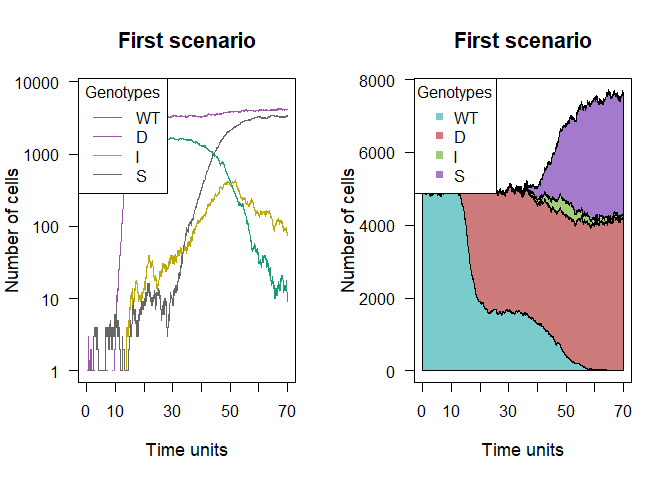

```r
scen1 <- allFitnessEffects(genotFitness = fitness_rel(a = 0.5, b = 0.7,
                                                     r = 0.1, g = 0.8),
                          frequencyDependentFitness = TRUE,
                          frequencyType = "rel")

set.seed(1)
simulScen1 <- oncoSimulIndiv(scen1,
                              model = "McFL",
                              onlyCancer = FALSE,
                              finalTime = 70,
                              mu = 1e-4,
                              initSize = 5000,
                              keepPhylog = TRUE,
                              seed = NULL,
                              errorHitMaxTries = FALSE,
                              errorHitWallTime = FALSE)
op <- par(mfrow = c(1, 2))
plot(simulScen1, show = "genotypes", type = "line",
     main = "First scenario",
     cex.main = 1.4, cex.lab = 1.1,
     las = 1)
plot(simulScen1, show = "genotypes",
     main = "First scenario",
     cex.main = 1.4, cex.lab = 1.1,
     las = 1)
```

```r
par(op)
```

To understand the stability of the results, we should run multiple simulations. We will not pursue that here. Note that the results can be sensitive to the initial population size and the mutation rate.

#### 11.4.1.2 Second scenario

In this case, we set $\alpha$ lower than in the first scenario and we enable the indepenence of I cells through a lower $\gamma$.

- $\alpha$ (a) = 0.3: low cooperation between D cells.
- $\beta$ (b) = 0.7: relatively resource-poor microenvironment.
- $\rho$ (r) = 0.1: low benefit of D cells from coexisting with I cells.
- $\gamma$ (g) = 0.7: lower cost of independence of I cells than in the first scenario.

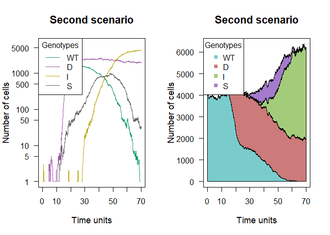

```r
scen2 <- allFitnessEffects(genotFitness = fitness_rel(a = 0.3, b = 0.7,
                                                     r = 0.1, g = 0.7),
                          frequencyDependentFitness = TRUE,
                          frequencyType = "rel")

set.seed(1)

simulScen2 <- oncoSimulIndiv(scen2,
                              model = "McFL",
                              onlyCancer = FALSE,
                              finalTime = 70,
                              mu = 1e-4,
                              initSize = 4000,
                              keepPhylog = TRUE,
                              seed = NULL,
                              errorHitMaxTries = FALSE,
                              errorHitWallTime = FALSE)
op <- par(mfrow = c(1, 2))
plot(simulScen2, show = "genotypes", type = "line",
     main = "Second scenario",
     cex.main = 1.4, cex.lab = 1.1,
     las = 1)
plot(simulScen2, show = "genotypes",
     main = "Second scenario",
     cex.main = 1.4, cex.lab = 1.1,
     las = 1)
```

```r
par(op)
```

#### 11.4.1.3 Third scenario

- $\alpha$ (a) = 0.2: low cooperation between D cells.
- $\beta$ (b) = 0.3: rich microenvironment, being beneficial for D cells.
- $\rho$ (r) = 0.1: low benefit of D cells from coexisting with I cells.
- $\gamma$ (g) = 0.3: independence costs very low, being beneficial for I cells.

Although $\gamma$ and $\rho$ are very low, which could make us think that I cells will control the tumour, we can observe that the fact that the microenvironment is very rich (with a low value of $\beta$) allows to D cells lead the progression of the tumour over the rest of cell populations, including I cells.

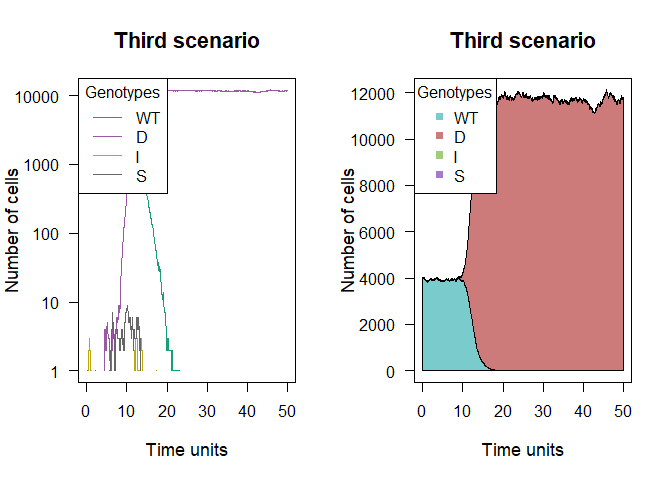

```r
scen3 <- allFitnessEffects(genotFitness = fitness_rel(a = 0.2, b = 0.3,
                                                     r = 0.1, g = 0.3),
                          frequencyDependentFitness = TRUE,
                          frequencyType = "rel")

set.seed(1)
simulScen3 <- oncoSimulIndiv(scen3,
                              model = "McFL",
                              onlyCancer = FALSE,
                              finalTime = 50,
                              mu = 1e-4,
                              initSize = 4000,
                              keepPhylog = TRUE,
                              seed = NULL,
                              errorHitMaxTries = FALSE,
                              errorHitWallTime = FALSE)
op <- par(mfrow = c(1, 2))
plot(simulScen3, show = "genotypes", type = "line",
     main = "Third scenario",
     cex.main = 1.4, cex.lab = 1.1,
     las = 1)
plot(simulScen3, show = "genotypes",
     main = "Third scenario",
     cex.main = 1.4, cex.lab = 1.1,
     las = 1)
```

```r
par(op)
```

#### 11.4.1.4 Fourth scenario

- $\alpha$ (a) = 0.2: low cooperation between D cells.
- $\beta$ (b) = 0.4: lower richness than in the previous scenario.
- $\rho$ (r) = 0.1: low benefit of D cells from coexisting with I cells.
- $\gamma$ (g) = 0.3: independence costs very low, being beneficial for I cells.

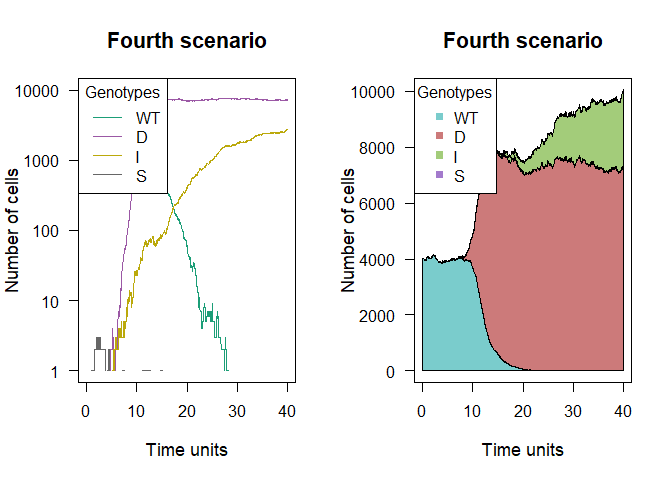

```r
scen4 <- allFitnessEffects(genotFitness = fitness_rel(a = 0.2, b = 0.4,
                                                     r = 0.1, g = 0.3),
                          frequencyDependentFitness = TRUE,
                          frequencyType = "rel")

## Set a different seed to show the results better since
## with set.seed(1) the progression of I cells was not shown
set.seed(2)

simulScen4 <- oncoSimulIndiv(scen4,
                              model = "McFL",
                              onlyCancer = FALSE,
                              finalTime = 40,
                              mu = 1e-4,
                              initSize = 4000,
                              keepPhylog = TRUE,
                              seed = NULL,
                              errorHitMaxTries = FALSE,
                              errorHitWallTime = FALSE)
op <- par(mfrow = c(1, 2))
plot(simulScen4, show = "genotypes", type = "line",
     main = "Fourth scenario",
     cex.main = 1.4, cex.lab = 1.1,
     las = 1)
plot(simulScen4, show = "genotypes",
     main = "Fourth scenario",
     cex.main = 1.4, cex.lab = 1.1,
     las = 1)
```

```r
par(op)
```

In this case, we can see that there is more variation in the size of population of I cells. There are cases where the I cell population cooperates with D cells and, in others, there is not cooperation. You can examine this running multiple simulations (or manually rerun the example above changing the seed).

## 11.5 Evolutionary Dynamics of Tumor-Stroma Interactions in Multiple Myeloma

This example is based on Sartakhti et al. (2016). The authors provide a frequency-dependent model to study the growth of malignant plasma cells in multiple myeloma. Assuming that cancer cells and stromal cells cooperate by exchanging diffusible factors, the study is carried out in the framework of evolutionary game theory.

We first need to define a payoff strategy for this kind of scenario. The following definitions are needed:

- There are $n$ phenotypes in a population denoted by $\{ P_1, \ldots, P_n \}$.
- Each phenotype can produce one diffusible factor $\{ G_1, \ldots, G_n \}$.
- Each diffusible factor $j$ has a different effect $r_{i,j}$ on the other phenotypes $i$.
- The cost for $P_i$ for growth factor $G_i$ is denoted as $c_i$.
- $M$ is the number of cells within the diffusion range.
- There are $M_j$ individuals of type $P_j$ among the other group members.

Then, the payoff for strategy $P_j$ is:
$$\begin{align}
\pi_{P_j}(M_1,\ldots,M_n)=\frac{(M_j+1)\times c_j}{M}r_{j,j} +
\sum_{i=1, i \neq j}^n \frac{M_i \times c_i}{M}r_{j,i} - c_j \;.
\end{align}$$

In multiple Myeloma we have three different types of cells that have autocrine and paracrine effects on the cells within their diffusion range: Malignant plasma cells (MM), Osteoblasts (OB) and Osteoclasts (OC). The specification of fitness is the following (see [10]):

$$\begin{align}
W_{OC} &= \frac{(f_{1}(M-1)+1)c_{1}}{M}r11+
\frac{((1-f_{3})(M-1)-f_{1}(M-1)-1)c_{2}}{M}r12 \\
&+\frac{(M-(1-f_3)(M-1))c_{3}}{M}r13-c_{1} \\
W_{OB} &= \frac{(f_{2}(M-1)+1)c_{2}}{M}r22+
\frac{((1-f_{1})(M-1)-f_{2}(M-1)-1)c_{3}}{M}r23 \\
&+\frac{(M-(1-f_{1})(M-1))c_{1}}{M}r21-c_{2} \\
W_{MM} &= \frac{(f_{3}(M-1)+1)c_{3}}{M}r33+
\frac{((1-f_{2})(M-1)-f_{3}(M-1)-1)c_{1}}{M}r31 \\
&+\frac{(M-(1-f_{2})(M-1))c_{2}}{M}r32-c_{3} \;,
\end{align}$$

where $f_1$, $f_2$ and $f_3$ denote the frequency of the phenotype OC, OB and MM in the population. The multiplication factors for diffusible factors produced by the cells are shown in the following table (taken from Sartakhti et al. (2016)):

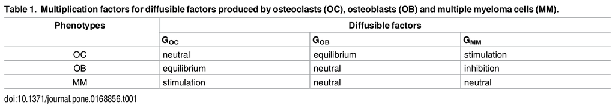

Figure 11.1: Multiplication factor in myeloma interaction. Table 1 in Sartakhti et al., 2016, ‘Evolutionary Dynamics of Tumor-Stroma Interactions in Multiple Myeloma’ https://doi.org/10.1371/journal.pone.0168856 .

Several scenarios varying the values of the parameters are shown in Sartakhti et al. (2016). Here we reproduce some of them.

### 11.5.1 Simulations

```r
f_cells <- function(c1, c2, c3, r11, r12, r13,
                    r21, r22, r23, r31, r32, r33, M, awt = 1e-4,
                                 gt = c("WT", "OC", "OB", "MM")) {
    data.frame(Genotype = gt,
               Fitness = c(
                  paste0("max(0.1, 1 - ", awt, " * (f_OC + f_OB+f_MM)*N)"),
                  paste0("1", "+(((f_OC * (", M, "-1)+1)*", c1, ")/", M, ")*",r11,
                          "+((((1-f_MM) * (", M, "-1)-f_OC*(", M, "-1)-1)*", c2, ")/", M, ")*", r12,
                          "+(((", M, "-(1-f_MM)*(", M, "-1))*", c3, ")/", M, ")*", r13,
                          "-", c1
                          ),
                  paste0("1", "+(((f_OB*(", M, "-1)+1)*", c2, ")/", M, ")*", r22,
                          "+((((1-f_OC)*(", M, "-1)-f_OB*(", M, "-1)-1)*", c3, ")/", M, ")*", r23,
                          "+(((", M, "-(1-f_OC)*(", M, "-1))*", c1, ")/", M, ")*", r21,
                          "-", c2
                          ),
                  paste0("1", "+(((f_MM*(", M, "-1)+1)*", c3, ")/", M, ")*", r33,
                          "+((((1-f_OB)*(", M, "-1)-f_MM*(", M, "-1)-1)*", c1, ")/", M, ")*", r31,
                          "+(((", M, "-(1-f_OB)*(", M, "-1))*", c2, ")/", M, ")*", r32,
                          "-", c3
                          )
                  )
               ,stringsAsFactors = FALSE
               )
}
```

It is important to note that, in order to exactly reproduce the experiments of the paper, we need to create an initial population with three different types of cell, but we do not need the presence of a wild type. For this reason, we will increase the probability of mutation of the wild type, which will disappear in early stages of the simulation; this is a procedure we have used before in several cases too (e.g., 11.2). This is something that we must consider when interpreting the results.

### 11.5.2 Scenario 1

Here we model a common situation in multiple myeloma in which $c_1<c_2<c_3$. In the presence of a small number of MM cells, the stable point on the OB-OC border becomes a saddle point and clonal selection leads to a stable coexistence of OC and MM cells. Parameters for the simulation can be seen in the R code.

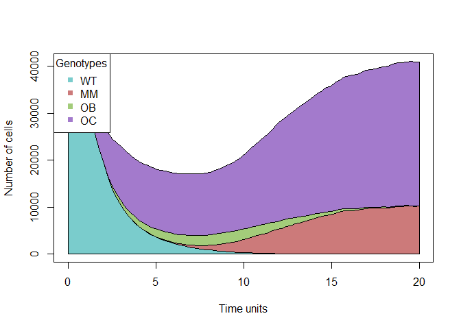

```r
N <- 40000
M <- 10
c1 <- 1
c2 <- 1.2
c3 <- 1.4
r11 <- 0
r12 <- 1
r13 <- 2.5
r21 <- 1
r22 <- 0
r23 <- -0.3
r31 <- 2.5
r32 <- 0
r33 <- 0

fe_cells <-
    allFitnessEffects(
        genotFitness =
            f_cells(c1, c2, c3, r11, r12, r13,
                    r21, r22, r23, r31, r32, r33, M,
                    gt = c("WT", "OC", "OB", "MM")),
        frequencyDependentFitness = TRUE,
        frequencyType = "rel")
## All single-gene genotypes as input to to_genotFitness_std

## Simulated trajectories
set.seed(2)
simulation <- oncoSimulIndiv(fe_cells,
                           model = "McFL",
                           onlyCancer = FALSE,
                           finalTime = 20, ## 30
                           mu = c("OC"=1e-1, "OB"=1e-1, "MM"=1e-4),
                           initSize = N,
                           keepPhylog = FALSE,
                           seed = NULL,
                           errorHitMaxTries = FALSE,
                           errorHitWallTime = FALSE)

## Plot trajectories
## op <- par(mfrow = c(1, 2))
## plot(simulation, show = "genotypes", type = "line")
plot(simulation, show = "genotypes", thinData = TRUE)
```

```r
## par(op)
```

Clearly, the appearance of MM cells quickly brings the system to an equilibrium point, which is stable. OB cells are extinct and cancer has propelled.

### 11.5.3 Scenario 2

As in the second scenario of [10] ($c1=c2=c3$) configuration A (upper row in the grid of images). We should find one stable point on the OC-OB edge under certain conditions, which are met in the example. Further information about the parameters can be found in the R code shown below.

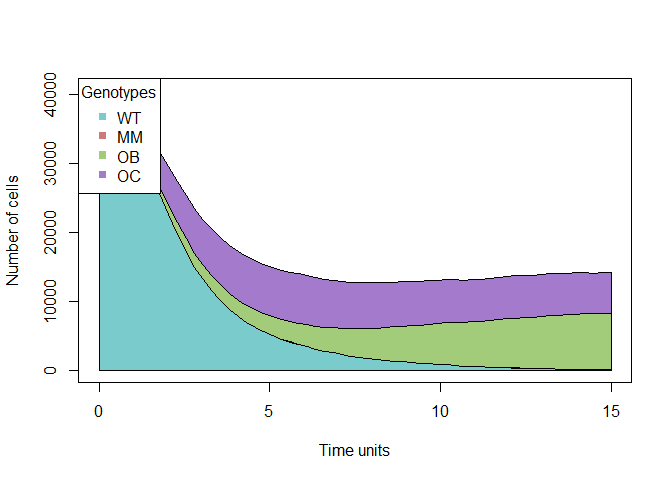

```r
N <- 40000
M <- 10
c1 <- 1
c2 <- 1
c3 <- 1
r11 <- 0
r12 <- 1
r13 <- 0.5
r21 <- 1
r22 <- 0
r23 <- -0.3
r31 <- 0.5
r32 <- 0
r33 <- 0

fe_cells <-
    allFitnessEffects(
        genotFitness =
            f_cells(c1, c2, c3, r11, r12, r13,
                    r21, r22, r23, r31, r32, r33, M,
                    gt = c("WT", "OC", "OB", "MM")),
        frequencyDependentFitness = TRUE,
        frequencyType = "rel")
## All single-gene genotypes as input to to_genotFitness_std

## Simulated trajectories
set.seed(1)
simulation <- oncoSimulIndiv(fe_cells,
                           model = "McFL",
                           onlyCancer = FALSE,
                           finalTime = 15, ## 25
                           mu = c("OC"=1e-1, "OB"=1e-1, "MM"=1e-4),
                           initSize = N,
                           keepPhylog = FALSE,
                           seed = NULL,
                           errorHitMaxTries = FALSE,
                           errorHitWallTime = FALSE)

#Plot trajectorie
plot(simulation, show = "genotypes", thinData = TRUE)
```

As expected, under these condtitions, MM cells are not able to propagate. The equilibrium point in the OB-OC edge is stable, resisting small variations in the number of MM cells.

## 11.6 An example of modellization in Parkinson disease related cell community

The following example is based on Masliah (2007), and it discusses the coexistance between cells that produce $\alpha$-synuclein and $\beta$-synuclein, related with pore-like oligomer development and Parkinson disease.

```r
park1<- data.frame(Genotype = c("WT", "A", "B", "A,B"),
                 Fitness = c("1",
                 "1 + 3*(f_1 + f_2 + f_1_2)",
                 "1 + 2*(f_1 + f_2 + f_1_2)", ## We establish
                 ## the fitness of B smaller than the one of A because
                 ## it is an indirect cause of the disease and not a direct one.
                 "1.5 + 4.5*(f_1 + f_2 + f_1_2)")) ## The baseline
                  ## of the fitness is higher in the
                  ## AB population (their growth is favored).

parkgen1<- allFitnessEffects(genotFitness = park1,
                         frequencyDependentFitness = TRUE,
                         frequencyType = "rel")
```

- $\alpha$- – normal a-synuclein production
- $\beta$- – normal b-synuclein production
- $\alpha$+ – deleterious a-synuclein production, causing aggregation and the rest of mentioned effects
- $\beta$+ – deleterious b-synuclein production, preventing it from slowing down the aggregation of a-synuclein
- WT - $\alpha$- and $\beta$- (balance)
- A - $\alpha$+ and $\beta$- (increases [slight] the probability of Parkinson’s disease)
- B – $\alpha$- and $\beta$+ (increases [slight] the probability of Parkinson’s disease)
- AB – $\alpha$+ and $\beta$+ (massive increase of probability of Parkinson’s disease)

In this simulation, at the very end, the only cells that remain alive are those from AB population (which means that both $\alpha$ and $\beta$ are mutated, $\alpha$+ and $\beta$+, which means that the individual has a high risk of developing the disease, and all the cells keep this mutation). Genotype AB is able to invade the population when there are some A’s and B’s around. Cooperation increases the fitness at 1.5 level respecting the fitness for just A’s or just B’s, so the rest of population (appart from AB) collapses. We can observe this cell behaviour in the following code and graphic:

```r
set.seed(1)
fpark1 <- oncoSimulIndiv(parkgen1,
                     model = "McFL",
                     onlyCancer = FALSE,
                     finalTime = 100,
                     mu = 1e-4,
                     initSize = 5000,
                     keepPhylog = TRUE,
                     seed = NULL,
                     errorHitMaxTries = FALSE,
                     errorHitWallTime = FALSE)
```

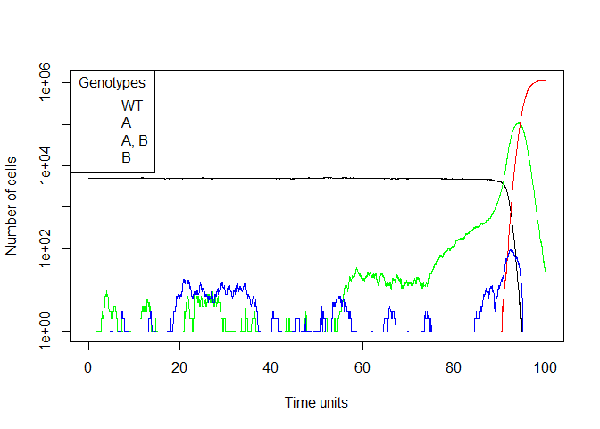

```r
plot(fpark1, show = "genotypes",  type = "line",
     col = c("black", "green", "red", "blue"))
```

Analyzing the graphic obtain from OncoSimulR we can see that A, B and the WT population dissapear at (more or less) the same point that AB population increases drastically, which makes sense because the fitness of AB population is greater than the other three population fitnesses. As the birth rate of the population depends directly of the fitness, at the end, just the AB population survives. We have a model of frequency-dependent fitness here, but the results are not really surprising given the fitness of each type, and no coexistence is possible.

The AB population comes mainly from the A population, as would be expected, because of its fitness, and abundance, relative to that of the B population:

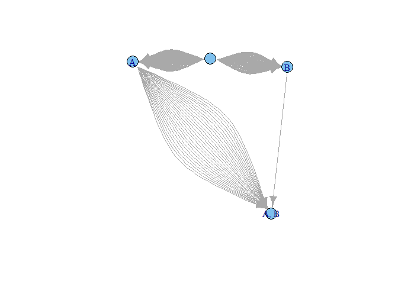

```r
plotClonePhylog(fpark1, N = 0, keepEvents=TRUE, timeEvents=TRUE)
```

## 11.7 Evolutionary Game between Commensal and Pathogenic Microbes in Intestinal Microbiota

The adapted payoff matrix obtained is shown in the next table.

Table 11.2: Payoff matrix for the adapted example from Wu A, Ross D., 2016, ‘Evolutionary Game between Commensal and Pathogenic Microbes in Intestinal Microbiota’. Games. 2016;7(3); doi: 10.3390/g7030026 .

|  | CS | CT | PA |
| --- | --- | --- | --- |
| **CS** | bG – cG – cS - ab | bG – cG – cS - ab | bG – cG – cS -cI - ab |
| **CT** | bG – cG – cS | bG – cG – cS | bG – cG – cS |
| **PA** | bPA – iPA - cS | bPA – cS | bPA – cS |

On the basis of the interactions between the different microbe populations and the payoff matrix, we establish fitness as:

- CS (Fcs = bG([CS] + [CT]) - cS*([CS] + [CT] + [PA]) - cI - cG - ab)
- CT (Fct = bG([CS] + [CT]) - cS*([CS] + [CT] + [PA]) - cG)
- PA (Fpa = bPA([PA]) - cS*([CS] + [CT] + [PA]) - iPA*[CS])

A function to create the data frame of frequency-dependent fitnesses is defined in order to be able to model situations with different values for the parameters, and it is assumed that WT derive to the other cell types by a single mutation.

```r
create_fe <- function(bG, cG, iPA, cI, cS, bPA, ab,
                      gt = c("WT", "CT", "PA")) {
  data.frame(Genotype = gt,
             Fitness = c(
               paste0("1 + ", bG, " * (f_ + f_CT) - ", cS,
                      " * (f_ +  f_CT + f_PA) - ", cI, "(f_PA > 0.2) - ", cG,
                      " - ", ab),
               paste0("1 + ", bG, " * (f_ + f_CT) - ", cS,
                      " * (f_ +  f_CT + f_PA) - ", cG),
               paste0("1 +", bPA, " - ", cS, " * (f_ +  f_CT + f_PA) - ", iPA,
                      " *(f_(f_PA > 0.2))")),
             stringsAsFactors = FALSE)
}
```

We can check we recover the Table 11.2 :

```r
create_fe("bG", "cG", "iPA", "cI", "cS", "bPA", "ab")
##   Genotype
## 1       WT
## 2       CT
## 3       PA
##                                                                      Fitness
## 1 1 + bG * (f_ + f_CT) - cS * (f_ +  f_CT + f_PA) - cI(f_PA > 0.2) - cG - ab
## 2                       1 + bG * (f_ + f_CT) - cS * (f_ +  f_CT + f_PA) - cG
## 3                  1 +bPA - cS * (f_ +  f_CT + f_PA) - iPA *(f_(f_PA > 0.2))
```

We verify what we have specified executing `evalAllGenotypes`. We specify populations sizes for evaluating fitness at different moments in the total population evolution.

In the absence of antibiotic we observe how, even though CS (WT) and CT population size is equal, CT fitness is greater than CS fitness due to the PA inhibitory factor releasing cost. PA fitness is decreased by means of this inhibitor produced by CS.

```r
evalAllGenotypes(allFitnessEffects(genotFitness =
                                   create_fe(7, 1, 9, 0.5, 2, 5, 0),
                                   frequencyDependentFitness = TRUE,
                                   frequencyType = "rel"),
                 spPopSizes = c(1000, 1000, 1000))
## All single-gene genotypes as input to to_genotFitness_std
## Warning in match_spPopSizes(spPopSizes, fmEffects): spPopSizes
## unnamed: cannot check genotype names.
##   Genotype  Fitness
## 1       WT 2.166667
## 2       CT 2.666667
## 3       PA 1.000000
## 4   CT, PA 0.000000
```

CS (WT) fitness decrease in the presence of antibiotic, while PA and CT fitness are not affected, and CT fitness is the largest.

```r
evalAllGenotypes(allFitnessEffects(genotFitness =
                                   create_fe(7, 1, 9, 0.5, 2, 5, 2),
                                   frequencyDependentFitness = TRUE,
                                   frequencyType = "rel"),
                 spPopSizes = c(1000, 1000, 1000))
## All single-gene genotypes as input to to_genotFitness_std
## Warning in match_spPopSizes(spPopSizes, fmEffects): spPopSizes
## unnamed: cannot check genotype names.
##   Genotype   Fitness
## 1       WT 0.1666667
## 2       CT 2.6666667
## 3       PA 1.0000000
## 4   CT, PA 0.0000000
```

In the extreme situation in in which antibiotic is administrated and only PA is present, neither WT (CS) nor CT would be able to grow:

```r
evalAllGenotypes(allFitnessEffects(genotFitness =
                                   create_fe(7, 1, 9, 0.5, 2, 5, 2),
                                   frequencyDependentFitness = TRUE,
                                   frequencyType = "rel"),
                 spPopSizes = c(0, 0, 1000))
## All single-gene genotypes as input to to_genotFitness_std
## Warning in match_spPopSizes(spPopSizes, fmEffects): spPopSizes
## unnamed: cannot check genotype names.
##   Genotype Fitness
## 1       WT       0
## 2       CT       0
## 3       PA       4
## 4   CT, PA       0
```

From a PA population size much greater than WT (CS) population size, the presence of WT decreases PA fitness via inhibitor production while WT fitness does not increase due to antibiotic administration.

```r
evalAllGenotypes(allFitnessEffects(genotFitness =
                                   create_fe(7, 1, 9, 0.5, 2, 5, 2),
                                   frequencyDependentFitness = TRUE,
                                   frequencyType = "rel"),
                 spPopSizes = c(100, 0, 1000))
## All single-gene genotypes as input to to_genotFitness_std
## Warning in match_spPopSizes(spPopSizes, fmEffects): spPopSizes
## unnamed: cannot check genotype names.
##   Genotype  Fitness
## 1       WT 0.000000
## 2       CT 0.000000
## 3       PA 3.181818
## 4   CT, PA 0.000000
```

```r
evalAllGenotypes(allFitnessEffects(genotFitness =
                                   create_fe(7, 1, 9, 0.5, 2, 5, 5),
                                   frequencyDependentFitness = TRUE,
                                   frequencyType = "rel"),
                 spPopSizes = c(1000, 0, 0))
## All single-gene genotypes as input to to_genotFitness_std
## Warning in match_spPopSizes(spPopSizes, fmEffects): spPopSizes
## unnamed: cannot check genotype names.
##   Genotype Fitness
## 1       WT       0
## 2       CT       5
## 3       PA       4
## 4   CT, PA       0
```

At the same WT and PA population size and with high antibiotic dose administration, the fitness of both of them is decreased to the same extent since they inhibit each other while CT grow a little.

```r
evalAllGenotypes(allFitnessEffects(genotFitness =
                   create_fe(7, 1, 9, 0.5, 2, 5, 5),
                   frequencyDependentFitness = TRUE,
                                   frequencyType = "rel"),
                 spPopSizes = c(1000, 0, 1000))
## All single-gene genotypes as input to to_genotFitness_std
## Warning in match_spPopSizes(spPopSizes, fmEffects): spPopSizes
## unnamed: cannot check genotype names.
##   Genotype Fitness
## 1       WT     0.0
## 2       CT     1.5
## 3       PA     0.0
## 4   CT, PA     0.0
```

We have verified that fitness specification gives the expected results:

Now we create `allFitnessEffects` object and simulate two different situations: microbiota evolution in the absence and presence of antibiotic. The model used is McFL so density dependence in the death rate is considered.

### 11.7.1 Antibiotic absence situation

We observe how CT and PA cells emerge at time 0 from WT mutations. PA population starts to grow but when its frequency is greater than the established threshold, 0.2, WT population produces inhibitory compounds which harm PA and affect its fitness; when its frequency is under that threshold, WT stop releasing inhibitory PA growth factor and PA starts to grow again. This loop remains over time. Meanwhile, WT population decreases slowly due to the cost of producing the inhibitor when PA frequency exceed the established 0.2 and is reached by CT population, which grow until WT and CT are stabilized and cohabit taking in account the cost for sharing space.

```r
woAntib <- allFitnessEffects(
  genotFitness = create_fe(7, 1, 9, 0.5, 2, 5, 0),
  frequencyDependentFitness = TRUE,
  frequencyType = "rel")

## We do not run this for speed but load it below
set.seed(2)
woAntibS <- oncoSimulIndiv(woAntib,
                        model = "McFL",
                        onlyCancer = FALSE,
                        finalTime = 2000,
                        mu = 1e-4,
                        initSize = 1000,
                        keepPhylog = FALSE,
                        seed = NULL,
                        errorHitMaxTries = FALSE,
                        errorHitWallTime = FALSE,
                        keepEvery = 2 ## store a smaller object
                        )
```

```r
## Load stored results
data(woAntibS)
```

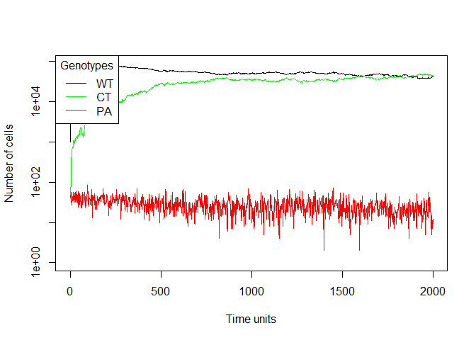

```r
plot(woAntibS, show = "genotypes", type = "line",
     col = c("black", "green", "red"))
```

### 11.7.2 Antibiotic presence situation

We observe how CT and PA cells emerge from WT mutations. WT cells decrease in number due to antibiotic administration and inhibitory PA growth factor when the frequency of this latest surpass the threshold imposed, so PA population grow with difficulty in comparison to CT. WT population finally disappear and CT and PA compete for resources, but CT takes over PA given its larger population size and CT population remain stable over time.

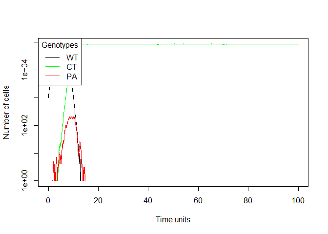

```r
wiAntib <- allFitnessEffects(
  genotFitness = create_fe(7, 1, 9, 0.5, 2, 5, 2),
  frequencyDependentFitness = TRUE,
  frequencyType = "rel")
## All single-gene genotypes as input to to_genotFitness_std


set.seed(2)
wiAntibS <- oncoSimulIndiv(wiAntib,
                        model = "McFL",
                        onlyCancer = FALSE,
                        finalTime = 100,
                        mu = 1e-4,
                        initSize = 1000,
                        keepPhylog = TRUE,
                        seed = NULL,
                        errorHitMaxTries = FALSE,
                        errorHitWallTime = FALSE)

plot(wiAntibS, show = "genotypes", type = "line",
     col = c("black", "green", "red"))
```

## 11.8 Modeling of breast cancer through evolutionary game theory.

The following example is based on Barton and Sendova (2018). This model assumes that there are four different types of cells in the body: (a) the native cells (NC), which are the healthy stromal cells; (b) the macrophages (Mph), which are part of the immune system; (c) the benign tumor cells (BTC), lump-forming cancer cells that lack the ability to metastasize; (d) the motile tumor cells (MTC), metastatic cancer cells that can invade neighboring tissues.

Both the native cells and macrophages produce growth factor, which benefits all types of cells.The cost of producing the growth factor, cG, and the benefits of the growth factor, bG, will be assumed to be the same for all types of the cells. The macrophages and motile tumor cells can move and we will assume that the ability comes at the costs cM,Mph, and cM,MTC respectively. The native cells and benign tumor cells stay in place and thus have to share the resources with other native and benign tumor cells, which comes at the cost cS. The cancer cells can reproduce faster than native cells or macrophages, which we model by additional benefit bR to the cancer cells, but the cancer cells can be destroyed by macrophages, which we model by additional cost cD to the cancer cells.

They provide also the payoff matrix reproduced in next table :

Table 11.3: Payoff matrix from Barton et al., 2018, ‘Modeling of breast cancer through evolutionary game theory’, Involve, a Journal of Mathematics, 11(4), 541-548; https://doi.org/10.2140/involve.2018.11.541 .

|  | MTC | Mph | NC | BTC |
| --- | --- | --- | --- | --- |
| **MTC** | bR - cMMTC | bR - cMMTC - cD + bG | bR - cMMTC + bG | bR - cMMTC |
| **Mph** | - cG - cMMph | bG - cG - cMMph | bG - cG - cMMph | -cG - cMMph |
| **NC** | - cG | bG - cG | bG - cG - cS | - cG - cS |
| **BTC** | bR | bR + bG - cD | bR + bG - cS | bR - cS |

Overall, when the concentrations of the cells are [NC], [Mph], [BTC] and [MTC], the net benefits (benefits minus the costs) to each type of the cells are:

- W(NC) = bG([NC] + [Mph]) - cG - cS([NC] + [BTC])
- W(Mph) = bG([NC] + [Mph]) - cG - cMMph
- W(BTC) = bR + bG([NC] + [Mph]) - cS([NC] + [BTC]) - cD[Mph]
- W(MTC) = bR + bG([NC] + [Mph]) - cMMTC - cD[Mph]

To allow modelling scenarios with different values for the parameters above we will define a function to create the data frame of frequency-dependent fitnesses. First, we will consider the NC cell type as the WT. Moreover, we will assume that each one of the other cell types types (Mph , BTC and MTC) are all derived from WT by a single mutation in one of three genes, say, O, B, M, respectively.

```r
create_fe <- function(cG, bG, cS, cMMph, cMMTC, bR, cD,
                      gt = c("WT", "Mph", "BTC", "MTC")) {
  data.frame(Genotype = gt,
             Fitness = c(
               paste0("1 + ", bG, "*(f_ + f_Mph) - ", cG, " - ", cS, "*(f_ + f_BTC)"),
               paste0("1 + ", bG, "*(f_ + f_Mph) - ", cG, " - ", cMMph),
               paste0("1 + ", bR, " + ", bG, "*(f_ + f_Mph) - ", cS, "* (f_ + f_BTC) -",
                      cD , " * f_Mph"),
               paste0("1 + ", bR, " + ", bG, " *(f_ + f_Mph) -", cMMTC, " - ",
                      cD , " * f_Mph")
               ),
             stringsAsFactors = FALSE)
}
```

We can check we recover the Table 11.3 :

```r
create_fe("cG", "bG","cS", "cMMph", "cMMTC", "bR", "cD")
##   Genotype                                                 Fitness
## 1       WT              1 + bG*(f_ + f_Mph) - cG - cS*(f_ + f_BTC)
## 2      Mph                        1 + bG*(f_ + f_Mph) - cG - cMMph
## 3      BTC 1 + bR + bG*(f_ + f_Mph) - cS* (f_ + f_BTC) -cD * f_Mph
## 4      MTC           1 + bR + bG *(f_ + f_Mph) -cMMTC - cD * f_Mph
```

We check that we have correctly specified the different parameters executing `evalAllGenotypes`. For this, we specify populations sizes for evaluating fitness at different moments in the total population evolution.

When there are only wild-type cells, the fitness of the cancer cells is higher than the other type of cells’ fitness. This makes sense, since there are no macrophages that can affect them.

```r
evalAllGenotypes(allFitnessEffects(genotFitness =
                                   create_fe(2, 5, 1, 0.8, 1, 1, 9),
                                   frequencyDependentFitness = TRUE,
                                   frequencyType = "rel"),
                 spPopSizes = c(WT = 1000, Mph = 0, BTC = 0, MTC = 0))
## All single-gene genotypes as input to to_genotFitness_std
##        Genotype Fitness
## 1            WT     3.0
## 2           BTC     6.0
## 3           Mph     3.2
## 4           MTC     6.0
## 5      BTC, Mph     0.0
## 6      BTC, MTC     0.0
## 7      Mph, MTC     0.0
## 8 BTC, Mph, MTC     0.0
```

In case that there are wild-type cells and macrophages, fitness of cancer cells is lower than before.

```r
evalAllGenotypes(allFitnessEffects(genotFitness =
                                   create_fe(2, 5, 1, 0.8, 1, 1, 9),
                                   frequencyDependentFitness = TRUE,
                                   frequencyType = "rel"),
                 spPopSizes = c(WT = 1000, Mph = 1000, BTC = 0, MTC = 0))
## All single-gene genotypes as input to to_genotFitness_std
##        Genotype Fitness
## 1            WT     3.5
## 2           BTC     2.0
## 3           Mph     3.2
## 4           MTC     1.5
## 5      BTC, Mph     0.0
## 6      BTC, MTC     0.0
## 7      Mph, MTC     0.0
## 8 BTC, Mph, MTC     0.0
```

When cancer cells start to grow, the fitness of wild type cells and macrophages decrease. This makes sense for wild-type cells, since they will share space with BTC cells, reducing their resources; and for macrophages, because the decrease of wild-type cells will affect the benefit of growth factor produced by them.

```r
evalAllGenotypes(allFitnessEffects(genotFitness =
                                   create_fe(2, 5, 1, 0.8, 1, 1, 9),
                                   frequencyDependentFitness = TRUE,
                                   frequencyType = "rel"),
                 spPopSizes = c(WT = 1000, Mph = 1000, BTC = 100, MTC = 100))
## All single-gene genotypes as input to to_genotFitness_std
##        Genotype  Fitness
## 1            WT 3.045455
## 2           BTC 1.954545
## 3           Mph 2.745455
## 4           MTC 1.454545
## 5      BTC, Mph 0.000000
## 6      BTC, MTC 0.000000
## 7      Mph, MTC 0.000000
## 8 BTC, Mph, MTC 0.000000
```

So, since the model seems correct, we create now the allFitnessEffects object and do the simulation. Here, we use the McFL model, with death density dependence in addition to the frequency dependence in the birth rates. In this case, we model three different situations: cancer being controlled, development of a non-metastatic cancer, and development of metastatic cancer.

### 11.8.1 Cancer kept under control

In this example, cD value is increased in order to represent a highly functioning immune system that helps fighting against cancer cells, while the cost of producing growth factor (cG) is low to allow a better fitness of non-cancer cells. This results in the fitness of wild-type cells and macrophages being kept in high levels, helping to control the proliferation of cancer cells, which is maintained under acceptable levels.

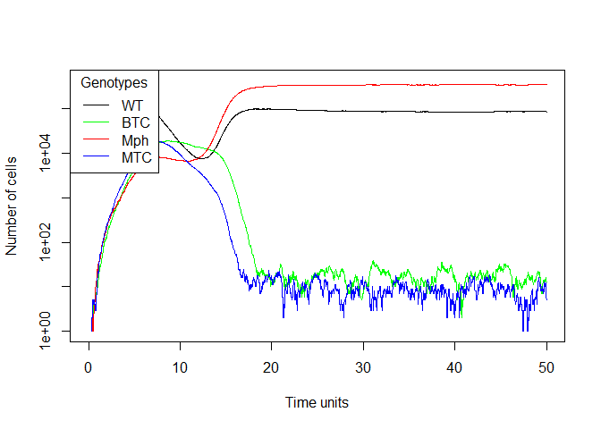

```r
afe_3_a <- allFitnessEffects(
  genotFitness =
    create_fe(0.5, 4, 1, 0.2, 1, 0.5, 4),
  frequencyDependentFitness = TRUE,
  frequencyType = "rel")
## All single-gene genotypes as input to to_genotFitness_std

set.seed(2)

s_3_a <- oncoSimulIndiv(afe_3_a,
                        model = "McFL",
                        onlyCancer = FALSE,
                        finalTime = 50,
                        mu = 1e-4,
                        initSize = 10000,
                        keepPhylog = TRUE,
                        seed = NULL,
                        errorHitMaxTries = FALSE,
                        errorHitWallTime = FALSE)

plot(s_3_a, show = "genotypes", type = "line",
     col = c("black", "green", "red", "blue", "yellow"))
```

### 11.8.2 Development of a non-metastatic cancer

In this second scenario, bR and cMMTC are increased, promoting a higher proliferative capacity of cancer cells but increasing the cost of the ability to move by metastatic cells (MTC), while Cs is slightly decreased, allowing a better fitness of non-motile cells that have to share resources (WT and BTC). This situation leads to the appearance of a non-metastatic cancer due to the higher fitness of BTC cells, thanks to their absence of mobility cost and their increased proliferative capacity, specially in the absence of other cell types that compete for resources.

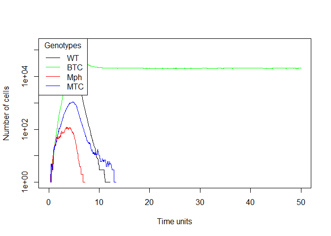

```r
afe_3_a <- allFitnessEffects(
  genotFitness =
    create_fe(1, 4, 0.5, 1, 1.5, 1, 4),
  frequencyDependentFitness = TRUE,
  frequencyType = "rel")
## All single-gene genotypes as input to to_genotFitness_std

set.seed(2)

s_3_a <- oncoSimulIndiv(afe_3_a,
                        model = "McFL",
                        onlyCancer = FALSE,
                        finalTime = 50,
                        mu = 1e-4,
                        initSize = 10000,
                        keepPhylog = TRUE,
                        seed = NULL,
                        errorHitMaxTries = FALSE,
                        errorHitWallTime = FALSE)


plot(s_3_a, show = "genotypes", type = "line",
     col = c("black", "green", "red", "blue", "yellow"))
```

### 11.8.3 Development of a metastatic cancer

In this last example, cS value is increased, hindering the growth and fitness of non-motile cells that compete for space and resources, whereas the cost of mobility of metastatic cancer cells (cMMTC) is considerably reduced, thus favoring their proliferation. This scenario leads to the development of metastatic cancer, due to a rapid increase in the proliferation of metastatic cancer cells, thanks to their low mobility cost, and a slightly slower increase in the fitness of benign tumor cells, that have to compete with resources with the wild-type cells until their disappearance.

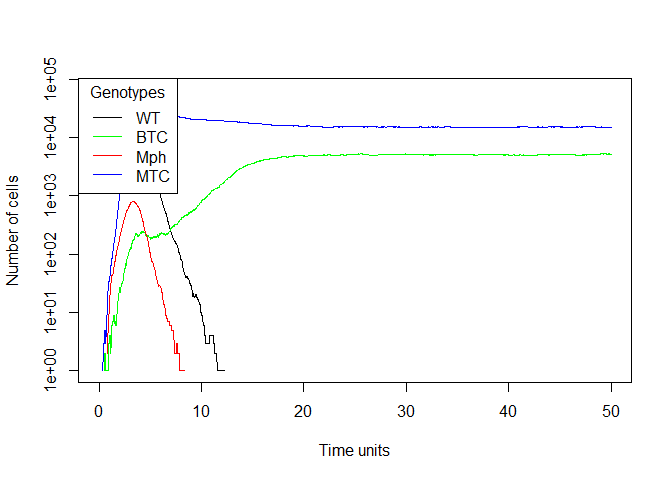

```r
afe_3_a <- allFitnessEffects(
  genotFitness =
    create_fe(0.5, 4, 2, 0.5, 0.5, 1, 4),
  frequencyDependentFitness = TRUE,
  frequencyType = "rel")
## All single-gene genotypes as input to to_genotFitness_std

set.seed(2)

s_3_a <- oncoSimulIndiv(afe_3_a,
                        model = "McFL",
                        onlyCancer = FALSE,
                        finalTime = 50,
                        mu = 1e-4,
                        initSize = 10000,
                        keepPhylog = TRUE,
                        seed = NULL,
                        errorHitMaxTries = FALSE,
                        errorHitWallTime = FALSE)


plot(s_3_a, show = "genotypes", type = "line",
     col = c("black", "green", "red", "blue", "yellow"))
```

## 11.9 Improving the previous example. Modeling of breast cancer with the presence chemotherapy and resistance.

With the aim of obtaining a more reliable and representative picture of what happens in a situation of cancer development and treatment, we model a more complex scenario inproving the previous example, 11.8.

This alternative model considers the presence of seven cell types, four of which are the same that have been described in the previous model: the native cells (NC), macrophages (Mph), benign tumor cells (BTC) and metastatic cancer cells (MTC). Moreover, we include here the chemotherapy-resistant normal cells (R), chemotherapy-resistant benign tumor cells (BTC,R) and chemotherapy-resistant metastatic cancer cells (MTC,R).

Most of the costs and benefits of this new model are similar to those described in the previous situation. Native cells and macrophages, but also the chemotherapy-resistant normal cells, produce growth factor bG, which benefits all cell types. These three cells types are considered to have the same cost of producing the growth factor, cG. The macrophages and motile tumor cells (both MTC and MTC,R) have the ability to move, assuming that the cost of this ability is cM,Mph, cM,MTC and cM,MTC,R respectively. The native cells and benign tumor cells (both BTC and BTC,R) have no motile capacity and have to stay in place, competing for the available resources with other native and benign tumor cells, which comes at the cost cS for all these cell types. As occurred in the previous model, considering that cancer cells have a higher reproductive rate than native cells or macrophages, we add an additional benefit bR to the cancer cells. However, as they can also be destroyed and attacked by macrophages, we add an additional cost cD to the cancer cells. Moreover, in this model we add an additional factor Q that represents the effect of chemotherapeutic treatment, which will not have any effect on cells that have been able to develop resistance to it, but it will have a negative effect on the rest of the cell types, being especially important on cancer cells, as they have a higher rate of reproduction.

The payoff matrix will also introduce slight changes, which reproduced in next table:

Table 11.4: Payoff matrix adapted from Barton et al., 2018, ‘Modeling of breast cancer through evolutionary game theory’, Involve, a Journal of Mathematics, 11(4), 541-548; https://doi.org/10.2140/involve.2018.11.541 .

|  | MTC | Mph | NC | BTC | R | BTC,R | MTC,R |
| --- | --- | --- | --- | --- | --- | --- | --- |
| **MTC** | bR - cMMTC - Q | bR - cMMTC - cD + bG -Q | bR - cMMTC + bG -Q | bR - cMMTC - Q | bR - cMMTC + bG - Q | bR - cMMTC - Q | bR - cMMTC -Q |
| **Mph** | - cG - cMMph - 0.01 * Q | bG - cG - cMMph - 0.01 * Q | bG - cG - cMMph - 0.01 * Q | -cG - cMMph - 0.01 * Q | bG - cG - cMMph- 0.01 * Q | -cG - cMMph - 0.01 * Q | - cG - cMMph - 0.01 * Q |
| **NC** | - cG - 0.01 * Q | bG - cG - 0.01 * Q | bG - cG - cS - 0.01 * Q | - cG - cS - 0.01 * Q | bG - cG - cS - 0.01 * Q | - cG - cS - 0.01 * Q | - cG - 0.01 * Q |
| **BTC** | bR - Q | bR + bG - cD - Q | bR + bG - cS - Q | bR - cS - Q | bR + bG - cS -Q | bR - cS - Q | bR - Q |
| **R** | - cG | bG - cG | bG - cG - cS | - cG - cS | bG - cG - cS | - cG - cS | - cG |
| **BTC,R** | bR | bR + bG - cD | bR + bG - cS | bR - cS | bR + bG - cS | bR - cS | bR |
| **MTC,R** | bR - cMMTC | bR - cMMTC - cD + bG | bR - cMMTC + bG | bR - cMMTC | bR - cMMTC + bG | bR - cMMTC | bR - cMMTC |

Now, we will define a function to create the data frame of frequency-dependent fitnesses to allow modelling several situations. As in the previous model, we will consider the NC cell type as the WT and will assume that Mph, BTC and MTC cells are all derived from WT by a single mutation, as previously described. Likewise, we consider that the chemotherapy-resistant normal cells (R) are derived from a single mutation in a gene, say, R. Furthermore, we will assume that the two chemotherapy-resistant cancer cells (BTC,R and MTC,R) are all derived from WT by two different mutations.

```r
create_fe <- function(cG, bG, cS, cMMph, cMMTC, bR, cD, Q,
                      gt = c("WT", "BTC", "R", "MTC", "Mph", "BTC,R", "MTC,R")) {
  data.frame(Genotype = gt,
             Fitness = c(

               paste0("1 + ", bG, "(f_ + f_R + f_Mph) - ", cG, " - ", cS, "(f_ + f_BTC + f_R + f_BTC_R) -",
                      "0.01*", Q),
               paste0("1 + ", bR, " + ", bG, "(f_ + f_R + f_Mph) - ", cS, " (f_ + f_BTC + f_R + f_BTC_R) -",
                      cD , " * f_Mph -", Q),
               paste0("1 + ", bG, "(f_ + f_R + f_Mph) - ", cG, " - ", cS, "(f_ + f_BTC + f_R + f_BTC_R)"),
               paste0("1 + ", bR, " + ", bG, " *(f_ + f_R + f_Mph) -", cMMTC, " - ",
                      cD , " * f_Mph -", Q),
               paste0("1 + ", bG, "(f_ + f_R + f_Mph) - ", cG, " - ", cMMph, "- 0.01*",Q),
               paste0("1 + ", bR, " + ", bG, "(f_ + f_R + f_Mph) - ", cS, " (f_ + f_BTC + f_R + f_BTC_R) -",
                      cD , " * f_Mph"),
               paste0("1 + ", bR, " + ", bG, " *(f_ + f_R + f_Mph) -", cMMTC, " - ",
                      cD , " * f_Mph")
             ),
             stringsAsFactors = FALSE)
}
```

We verify that we recover Table 11.4 :

```r
create_fe("cG", "bG","cS", "cMMph", "cMMTC", "bR", "cD", "Q")
##   Genotype
## 1       WT
## 2      BTC
## 3        R
## 4      MTC
## 5      Mph
## 6    BTC,R
## 7    MTC,R
##                                                                          Fitness
## 1         1 + bG(f_ + f_R + f_Mph) - cG - cS(f_ + f_BTC + f_R + f_BTC_R) -0.01*Q
## 2 1 + bR + bG(f_ + f_R + f_Mph) - cS (f_ + f_BTC + f_R + f_BTC_R) -cD * f_Mph -Q
## 3                 1 + bG(f_ + f_R + f_Mph) - cG - cS(f_ + f_BTC + f_R + f_BTC_R)
## 4                         1 + bR + bG *(f_ + f_R + f_Mph) -cMMTC - cD * f_Mph -Q
## 5                                  1 + bG(f_ + f_R + f_Mph) - cG - cMMph- 0.01*Q
## 6    1 + bR + bG(f_ + f_R + f_Mph) - cS (f_ + f_BTC + f_R + f_BTC_R) -cD * f_Mph
## 7                            1 + bR + bG *(f_ + f_R + f_Mph) -cMMTC - cD * f_Mph
```

We check once again that we have correctly specified the different parameters executing evalAllGenotypes. We are trying the same case than in the previous example, having wild-type cells, macrophages and both cancer cells. But in this case, we are introducing the parameter “Q” (chemotherapy), with a value of 5.

```r
evalAllGenotypes(allFitnessEffects(genotFitness =
                                   create_fe(2,5,1,0.8,1,1,9,5),
                                   frequencyDependentFitness = TRUE,
                                   frequencyType = "rel"),
                 spPopSizes = c(WT = 1000, BTC = 100, R = 0,
                                MTC = 100, Mph = 1000,
                                "BTC, R" = 0, "MTC, R" = 0))
##            Genotype  Fitness
## 1                WT 2.995455
## 2               BTC 0.000000
## 3               Mph 2.695455
## 4               MTC 0.000000
## 5                 R 3.045455
## 6          BTC, Mph 0.000000
## 7          BTC, MTC 0.000000
## 8            BTC, R 1.954545
## 9          Mph, MTC 0.000000
## 10           Mph, R 0.000000
## 11           MTC, R 1.454545
## 12    BTC, Mph, MTC 0.000000
## 13      BTC, Mph, R 0.000000
## 14      BTC, MTC, R 0.000000
## 15      Mph, MTC, R 0.000000
## 16 BTC, Mph, MTC, R 0.000000
```

As we can see, BTC and MTC have a fitness of 0, so the will not proliferate. But cancer cells mutants with a double mutation (BTC, R and MTC, R) are resistant to chemotherapy, so they can still grow. This is what we were expecting to happen, so we started with the simulation.

Now, we create the allFitnessEffects object and do the simulation using the McFL model. In this case, we specify gene-specific mutations rates, so we can model a more realistic scenario where the appearence of chemotherapy-resistant cells is hindered. Once again, we simulate different situations by changing the values of the different parameters.

### 11.9.1 Absence of chemotherapy

In the first scenario, we simulate a situation where no chemotherapy is applied. In this condition, there is a very low R mutation rate, which hampers the proliferation of chemotherapy-resistant cells. A fast appearance of macrophages is observed, as well as non-resistant tumor cells. As there is no chemoterapy treatment, the fitness of non-resistant tumor cells is favoured against macrophages, leading to the appearance of cancer, where BTC cells show the greatest fitness due to the mobility cost of MTC cells.

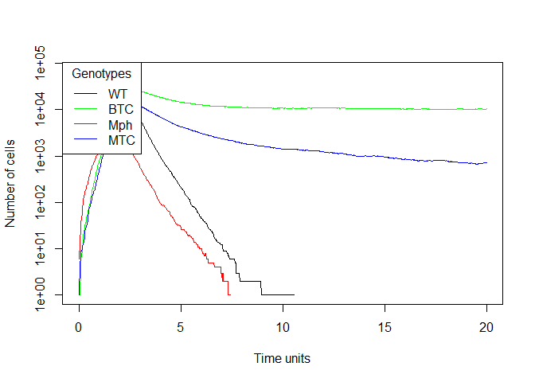

```r
afe_3_a <- allFitnessEffects(
  genotFitness =
    create_fe(2, 5, 1, 0.8, 1, 1, 9, 0),
  frequencyDependentFitness = TRUE,
  frequencyType = "rel")

#Set mutation rates
muvar2 <- c("Mph" = 1e-2, "BTC" = 1e-3, "MTC"=1e-3, "R" = 1e-7)

set.seed(2)
s_3_a <- oncoSimulIndiv(afe_3_a,
                        model = "McFL",
                        onlyCancer = FALSE,
                        finalTime = 20,
                        mu = muvar2,
                        initSize = 10000,
                        keepPhylog = TRUE,
                        seed = NULL,
                        errorHitMaxTries = FALSE,
                        errorHitWallTime = FALSE)


plot(s_3_a, show = "genotypes", type = "line",
     col = c("black", "green", "red", "blue", "pink", "orange", "brown"))
```

### 11.9.2 Chemotherapy with low R mutation rate

In the second scenario, we perform a simulation including chemotherapy as a treatment. However, here we maintain a low R mutation rate, hampering once again the appearance of chemotherapy-resistant cells. This situation can be reflecting the application of a combination chemotherapy that reduces or limits the appearance of resistance. We observe that the fitness of wild-type cells and macrophages increases rapidly and remains elevated, while tumor cells undergo some proliferation at first, but it remains under control over time thanks to the negative effect on them of chemotherapy.

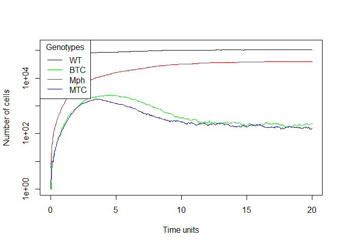

```r
afe_3_a <- allFitnessEffects(
  genotFitness =
    create_fe(2, 5, 1, 0.8, 1, 1, 9, 2),
  frequencyDependentFitness = TRUE,
  frequencyType = "rel")

muvar2 <- c("Mph" = 1e-2, "BTC" = 1e-3, "MTC"=1e-3, "R" = 1e-7)

set.seed(2)

s_3_a <- oncoSimulIndiv(afe_3_a,
                        model = "McFL",
                        onlyCancer = FALSE,
                        finalTime = 20,
                        mu = muvar2,
                        initSize = 10000,
                        keepPhylog = FALSE,
                        seed = NULL,
                        errorHitMaxTries = FALSE,
                        errorHitWallTime = FALSE)


plot(s_3_a, show = "genotypes", type = "line",
     col = c("black", "green", "red", "blue", "pink", "orange", "brown"))
```

### 11.9.3 Chemotherapy with considerable R mutation rate

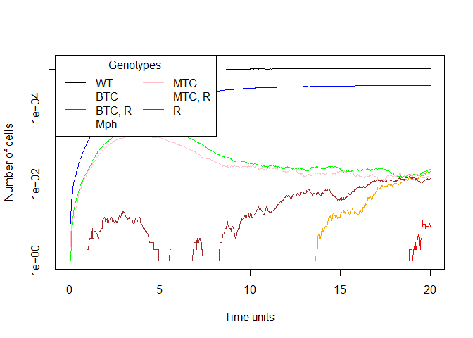

```r
afe_3_a <- allFitnessEffects(
  genotFitness =
    create_fe(2, 5, 1, 0.8, 1, 1, 9, 2),
  frequencyDependentFitness = TRUE,
  frequencyType = "rel")

muvar2 <- c("Mph" = 1e-2, "BTC" = 1e-3, "MTC"=1e-3, "R" = 1e-5)

set.seed(2)

s_3_a <- oncoSimulIndiv(afe_3_a,
                        model = "McFL",
                        onlyCancer = FALSE,
                        finalTime = 20, ## short for speed; increase for "real"
                        mu = muvar2,
                        initSize = 10000,
                        keepPhylog = FALSE,
                        seed = NULL,
                        errorHitMaxTries = FALSE,
                        errorHitWallTime = FALSE)


plot(s_3_a, show = "genotypes", type = "line",
     col = c("black", "green", "red", "blue", "pink", "orange", "brown"))
```

# 12 Simulating therapeutic interventions that depend on time

In this section we show some examples using the time dependent functionality; with it, fitness can be made to depend on T, the current time defined in the simulation. These examples were originally prepared by Niklas Endres, Rafael Barrero Rodríguez, Rosalía Palomino Cabrera and Silvia Talavera Marcos, as an exercisse for the course Programming and Statistics with R (Master’s Degree in Bioinformatics and Computational Biology, Universidad Autónoma de Madrid), course 2019-20; Niklas Endres had the idea of accessing T from exprTk.

This first example is an artificial simulation, but it shows how the fitness of a genotype can suddenly increase at a certain given timepoint.

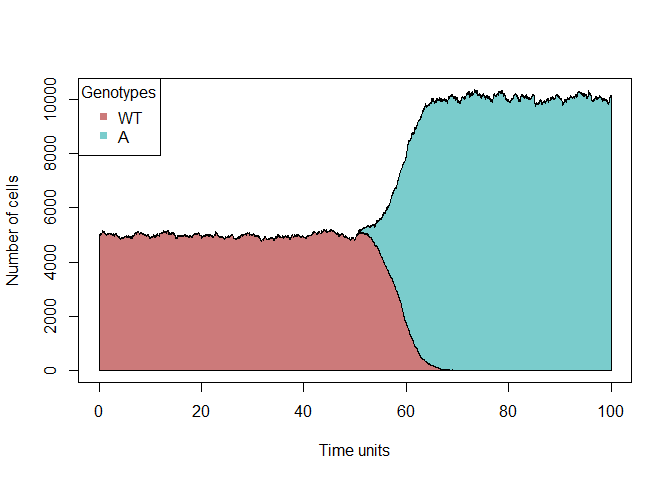

```r
## Fitness definition
fl <- data.frame(
  Genotype = c("WT", "A", "B"),
  Fitness = c("1",                       #WT
              "if (T>50) 1.5; else 0;",  #A
              "0*f_") ,                  #B
  stringsAsFactors = FALSE
)

fe <- allFitnessEffects(genotFitness = fl,
                        frequencyDependentFitness = TRUE,
                        frequencyType = "rel")
## All single-gene genotypes as input to to_genotFitness_std

## Evaluate the fitness before and after the specified currentTime
evalAllGenotypes(fe, spPopSizes = c(100, 100, 100))
## Warning in match_spPopSizes(spPopSizes, fmEffects): spPopSizes
## unnamed: cannot check genotype names.
##   Genotype Fitness
## 1       WT       1
## 2        A       0
## 3        B       0
## 4     A, B       0
evalAllGenotypes(fe, spPopSizes = c(100, 100, 100), currentTime = 80)
## Warning in match_spPopSizes(spPopSizes, fmEffects): spPopSizes
## unnamed: cannot check genotype names.
##   Genotype Fitness
## 1       WT     1.0
## 2        A     1.5
## 3        B     0.0
## 4     A, B     0.0

## Simulation
sim <- oncoSimulIndiv(fe,
                      model = "McFL",
                      onlyCancer = FALSE,
                      finalTime = 100,
                      mu = 0.01,
                      initSize = 5000,
                      keepPhylog = FALSE,
                      seed = NULL,
                      errorHitMaxTries = FALSE,
                      errorHitWallTime = FALSE)

## Plot the results
plot(sim, show = "genotypes")
```

## 12.1 Adaptive control of competitive release and chemotherapeutic resistance

The code structure of the previous example can be used, for instance, to simulate the effect of different chemotherapy treatment protocols.

An example of using these game theory concepts is the adaptive theory. The primary goal is to maximize the time of tumor control by using the tumor cells that are sensitive to treatment as agents that can supress the proliferation of the resistant cells. Thus, a significant residual populations of tumor cells can be under control to inhibit the growth of cells that otherwise cannot control: killed vs resistant.

Newton and Ma Newton and Ma (2019) built simulations for a tumor consisting in two types of cells: resistant to chemotherapy and sensitive to chemotherapy. The idea is to promote competition among tumor cells in order to prevent tumor growth.

To do this, they developed a **three-component Prisoner’s Dilemma scenario** including healthy (**H**) cells as well as chemoresistant (**R**) and chemosensitive (**S**) cancer cells. Healthy cells are cooperators, while cancer cells are defectors.

This is the system’s payoff matrix:

```r
a <- 1;     b <- 0.5;  c <- 0.5    ## a b c
d <- 1;     e <- 1.25; f <- 0.7    ## d e f
g <- 0.975; h <- -0.5; i <- 0.75   ## g h i

payoff_m <- matrix(c(a,b,c,d,e,f,g,h,i), ncol=3, byrow=TRUE)
colnames(payoff_m) <- c("Healthy", "Chemo-sensitive", "Chemo-resistant")
rownames(payoff_m) <- c("Healthy", "Chemo-sensitive", "Chemo-resistant")
print(payoff_m <- as.table(payoff_m))
##                 Healthy Chemo-sensitive Chemo-resistant
## Healthy           1.000           0.500           0.500
## Chemo-sensitive   1.000           1.250           0.700
## Chemo-resistant   0.975          -0.500           0.750
```

Thus, the fitness definitions for the three types of cells could be written as in the following data frame:

```r
print( df <- data.frame(
  CellType = c("H", "S", "R"),
  Fitness = c("F(H) = ax(H) + bx(S) + cx(R)",    #Healthy
              "F(S) = dx(H) + ex(S) + fx(R)",    #Sensitive
              "F(R) = gx(H) + hx(S) + ix(R)")),  #Resistant
  row.names = FALSE )
##  CellType                      Fitness
##         H F(H) = ax(H) + bx(S) + cx(R)
##         S F(S) = dx(H) + ex(S) + fx(R)
##         R F(R) = gx(H) + hx(S) + ix(R)
```

In summary:

- The fitness of H cells is lower than the chemosensitive cells.
- Without any therapy, S cells have a higher fitness value than R cells, because of the cost to resistance
- In the presence of therapy, R cells take over the S cells

One of the challenges is to optimize the drug dosage intervals. In practice, this would mean to infer the growth rates of the different cell types from a frequent monitoring of the tumor environment. With OncoSimulR is possible to try out different intervals on simulations of the collected data.